# Analyzing Phrases with tidytext

As always, we set the working directory and then load the packages we want.

```r
library(tidyverse)
library(tidytext)
library(okcupiddata)
library(scales) # scale functions for visualization
library(igraph)
library(ggraph)
```

We continue the analysis of the OKCupid essays, and just to add some further interests we compare responses of smokers and non-smokers.

For clarity, let’s break the process down into steps. First, subset the okcupid `profiles` to include just the essay responses and the user’s response about smoking. The `data_frame` function creates a tibble. In creating the tibble, we rename `essay0` as `text` – not necessary, but follows the example in Silge and Robinson.

Then we create a new binary variable, `smoker` that identifies non-smokers as “no” and everyone else as “yes”, dropping the original `smokes` variable (notice the command `select(-smokes)`, which selects all columns *except for* `smokes`.

```r
tidy_okcupid <- select_(profiles,"essay0","smokes")

tidy_okcupid <- data_frame(smokes=profiles$smokes,text=profiles$essay0)
tidy_okcupid <- tidy_okcupid %>%
     mutate(smoker = ifelse(smokes=="no","no","yes")) %>%
     select(-smokes)
```

```r
tidy_smoker <- tidy_okcupid %>%
     select(smoker, text) %>%
     na.omit()

smoker_bigrams <- unnest_tokens(tidy_smoker, bigram, text, token="ngrams", n=2)

smoker_bigrams
```

```
## # A tibble: 1,226,066 x 2
##    smoker bigram
##    <chr>  <chr>
##  1 no     i am
##  2 no     am a
##  3 no     a chef
##  4 no     chef this
##  5 no     this is
##  6 no     is what
##  7 no     what that
##  8 no     that means
##  9 no     means 1
## 10 no     1 i
## # ... with 1,226,056 more rows
```

At this point, the tibble `smoker_bigrams` consists of more than 1,226,000 pairs of adjacent words. The next code chunk counts and sorts the pairs to find the most common ones. After that, it `separate`s the pairs into `word1` and `word2` to search for and remove stopwords, and then `unite`s the pairs that remain, finally recounting and sorting the shorter list of pairs.

Consult Silge & Robinson to learn how to customize the list of stopwords.

```r
smoker_bigrams %>%
     count(bigram, sort = TRUE)
```

```
## # A tibble: 323,132 x 2
##    bigram            n
##    <chr>         <int>
##  1 i am          14243
##  2 i'm a          6571
##  3 i love         6445
##  4 in the         5275
##  5 i like         4480
##  6 i have         4346
##  7 am a           4215
##  8 and i          3382
##  9 san francisco  3269
## 10 like to        3128
## # ... with 323,122 more rows
```

```r
bigrams_separated <- smoker_bigrams %>%
     separate(bigram, c("word1", "word2"), sep = " ")

bigrams_filtered <- bigrams_separated %>%
     filter(!word1 %in% stop_words$word) %>%
     filter(!word2 %in% stop_words$word)

# new bigram counts:
bigram_counts <- bigrams_filtered %>%
     count(word1, word2, smoker, sort = TRUE)


bigram_counts
```

```
## # A tibble: 105,832 x 4
##    word1    word2     smoker     n
##    <chr>    <chr>     <chr>  <int>
##  1 san      francisco no      2669
##  2 east     coast     no       750
##  3 san      francisco yes      600
##  4 fun      loving    no       537
##  5 recently moved     no       449
##  6 east     bay       no       254
##  7 online   dating    no       229
##  8 enjoy    life      no       214
##  9 grad     school    no       208
## 10 san      diego     no       187
## # ... with 105,822 more rows
```

```r
bigrams_united <- bigrams_filtered %>%
     unite(bigram, word1, word2, sep = " ")

bigrams_united
```

```
## # A tibble: 159,694 x 2
##    smoker bigram
##    <chr>  <chr>
##  1 no     means 1
##  2 no     workaholic 2
##  3 no     writing public
##  4 no     public text
##  5 no     online dating
##  6 no     dating site
##  7 no     site makes
##  8 no     pleasantly uncomfortable
##  9 no     school hey
## 10 no     australian living
## # ... with 159,684 more rows
```

As noted in class and in the readings, a simple frequency count can be misleading. The next code chunk weights term frequency by the inverse frequency within the documents (smokers vs non-smokers.

```r
     bigram_tf_idf <- bigrams_united %>%
          count(smoker, bigram) %>%
          bind_tf_idf(bigram, smoker, n) %>%
          arrange(desc(tf_idf))

     bigram_tf_idf
```

```
## # A tibble: 105,832 x 6
##    smoker bigram                     n       tf   idf   tf_idf
##    <chr>  <chr>                  <int>    <dbl> <dbl>    <dbl>
##  1 yes    words 500                 13 0.000436 0.693 0.000302
##  2 yes    uh uh                      7 0.000235 0.693 0.000163
##  3 yes    smoke cigarettes           6 0.000201 0.693 0.000140
##  4 no     playing tennis            25 0.000192 0.693 0.000133
##  5 no     running hiking            24 0.000185 0.693 0.000128
##  6 no     bike riding               23 0.000177 0.693 0.000123
##  7 no     meow meow                 22 0.000169 0.693 0.000117
##  8 no     intellectually curious    20 0.000154 0.693 0.000107
##  9 no     mountain view             19 0.000146 0.693 0.000101
## 10 no     school teacher            19 0.000146 0.693 0.000101
## # ... with 105,822 more rows
```

```r
     bigrams_separated %>%
          filter(word1 == "not") %>%
          count(word1, word2, sort = TRUE)
```

```
## # A tibble: 995 x 3
##    word1 word2       n
##    <chr> <chr>   <int>
##  1 not   a         365
##  2 not   to        227
##  3 not   really    213
##  4 not   sure      196
##  5 not   looking   165
##  6 not   the       146
##  7 not   so        111
##  8 not   in         97
##  9 not   very       96
## 10 not   too        84
## # ... with 985 more rows
```

[figure not shown]

```r
plot_pairs <- bigram_tf_idf %>%
  arrange(desc(tf_idf)) %>%
  mutate(pair = factor(bigram, levels = rev(unique(bigram))))

plot_pairs %>%
  group_by(smoker) %>%
  top_n(15) %>%
  ungroup %>%
  ggplot(aes(pair, tf_idf, fill = smoker)) +
  geom_col(show.legend = FALSE) +
  labs(x = NULL, y = "tf-idf") +
  facet_wrap(~smoker, ncol = 2, scales = "free") +
  coord_flip()
```

# Sentiment Analysis

DataCamp introduced you to Sentiment Analysis. This next chunk follows the Silge & Robinson example. We specifically look for word pairs beginning that include negation (like “not”), since that can be a common style.

```r
     AFINN <- get_sentiments("afinn")

     not_words <- bigrams_separated %>%
          filter(word1 == "not") %>%
          inner_join(AFINN, by = c(word2 = "word")) %>%
          count(word2, score, sort = TRUE) %>%
          ungroup()

     not_words
```

```
## # A tibble: 168 x 3
##    word2      score     n
##    <chr>      <int> <int>
##  1 good           3    70
##  2 afraid        -2    63
##  3 like           2    45
##  4 interested     2    42
##  5 easy           1    23
##  6 shy           -1    23
##  7 great          3    22
##  8 perfect        3    17
##  9 want           1    13
## 10 crazy         -2     9
## # ... with 158 more rows
```

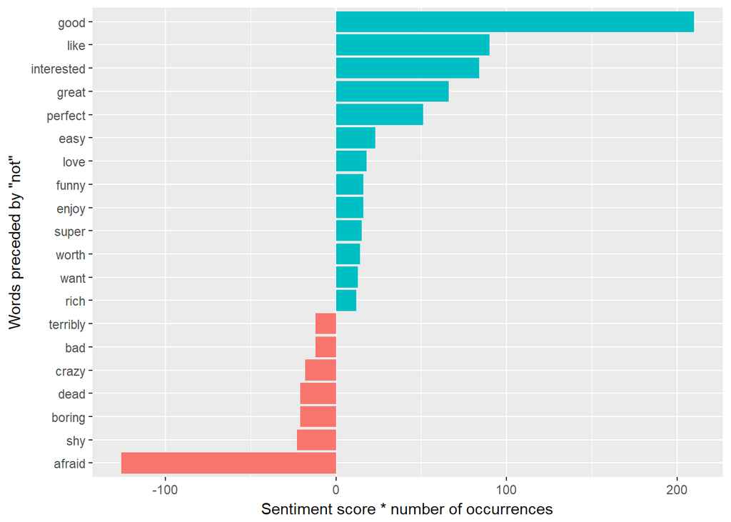

```r
     not_words %>%
          mutate(contribution = n * score) %>%
          arrange(desc(abs(contribution))) %>%
          head(20) %>%
          mutate(word2 = reorder(word2, contribution)) %>%
          ggplot(aes(word2, n * score, fill = n * score > 0)) +
          geom_col(show.legend = FALSE) +
          xlab("Words preceded by \"not\"") +
          ylab("Sentiment score * number of occurrences") +
          coord_flip()
```

```r
     negation_words <- c("not", "no", "never", "without")

     negated_words <- bigrams_separated %>%
          filter(word1 %in% negation_words) %>%
          inner_join(AFINN, by = c(word2 = "word")) %>%
          count(word1, word2, score, sort = TRUE) %>%
          ungroup()
```

```r
     # original counts
     bigram_counts
```

```
## # A tibble: 105,832 x 4
##    word1    word2     smoker     n
##    <chr>    <chr>     <chr>  <int>
##  1 san      francisco no      2669
##  2 east     coast     no       750
##  3 san      francisco yes      600
##  4 fun      loving    no       537
##  5 recently moved     no       449
##  6 east     bay       no       254
##  7 online   dating    no       229
##  8 enjoy    life      no       214
##  9 grad     school    no       208
## 10 san      diego     no       187
## # ... with 105,822 more rows
```

```r
# filter for only relatively common combinations
# might want to experiment with values other than 20 in filter line
     bigram_graph <- bigram_counts %>%
          group_by(smoker) %>%
          filter(n > 20) %>%
          filter(smoker=="yes") %>%
          graph_from_data_frame()

     bigram_graph
```

```
## IGRAPH 9f83967 DN-- 49 33 --
## + attr: name (v/c), smoker (e/c), n (e/n)
## + edges from 9f83967 (vertex names):
##  [1] san     ->francisco  recently->moved      fun     ->loving
##  [4] east    ->coast      love    ->music      east    ->bay
##  [7] online  ->dating     san     ->diego      months  ->ago
## [10] blah    ->blah       people  ->laugh      pretty  ->laid
## [13] meet    ->people     nice    ->guy        pretty  ->easy
## [16] video   ->games      enjoy   ->life       live    ->life
## [19] free    ->time       west    ->coast      love    ->life
## [22] san     ->franciscan southern->california love    ->traveling
## + ... omitted several edges
```

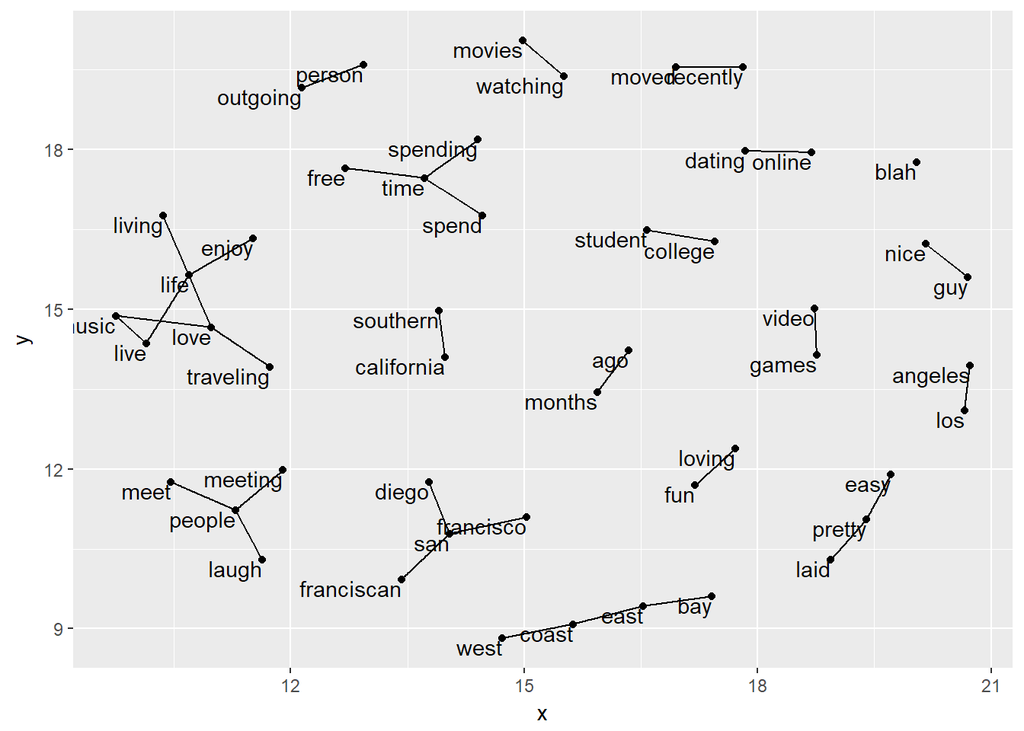

```r
     set.seed(2018)

     ggraph(bigram_graph, layout = "fr") +
          geom_edge_link() +
          geom_node_point() +
          geom_node_text(aes(label = name),  vjust = 1, hjust = 1)
```

Finally, as in Chapter 4 of Silge and Robinson (which was not assigned), here’s an alternative and more attractive network graph. This will use the same subset of participants as the one created above.

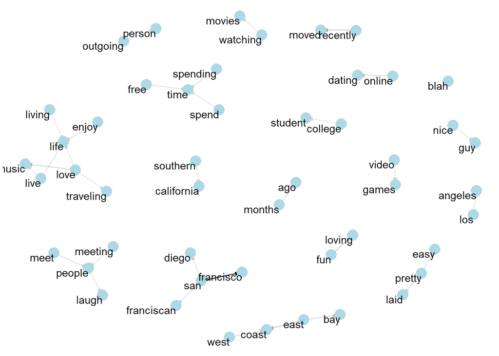

```r
     set.seed(2018)

     a <- grid::arrow(type = "closed", length = unit(.05, "inches"))

     ggraph(bigram_graph, layout = "fr") +
          geom_edge_link(aes(edge_alpha = n), show.legend = FALSE,
                         arrow = a, end_cap = circle(.05, 'inches')) +
          geom_node_point(color = "lightblue", size = 5) +
          geom_node_text(aes(label = name), vjust = 1, hjust = 1) +
          theme_void()
```